# Predicting Canadian Annual Income Through Census Data

2025-03-12

**First Version:** 2023-04-19  
**Latest Version:** 2025-03-12

```r
version
```

```
##                _
## platform       aarch64-apple-darwin20
## arch           aarch64
## os             darwin20
## system         aarch64, darwin20
## status
## major          4
## minor          3.2
## year           2023
## month          10
## day            31
## svn rev        85441
## language       R
## version.string R version 4.3.2 (2023-10-31)
## nickname       Eye Holes
```

```r
library(haven)
library(ggplot2)
library(randomForest)
library(caret)
library(cvms)
library(ggimage)
library(rsvg)
library(ROCR)
library(pROC)
library(tibble)
library(scales)
library(dplyr)
```

# Dataset and Data Preparation

## 2016 Census Public Use Microdata File (PUMF)

Released by Statistics Canada, the 2016 Census Public Use Microdata File (PUMF) features 123 variables on various individual and family-level socioeconomic characteristics surveyed during the 2015-2016 Census. It includes a total of 930,421 observations representing 2.7% of the entire population living within Canadian territory at the time of the census. An estimated weight is also attached to each observation to represent the total number of people in the population that share the respondent’s characteristics.

```r
cdata16_origin <- read_sav('./Census_2016_Individual_PUMF.sav')
cdata16 <- cdata16_origin
# total records
nrow(cdata16)
```

```
## [1] 930421
```

## Dependent Variables

There are 32 features under the income category in the 2016 census data that represent different measurements of the variable. The variable **TOTINC** (Total Income) has been chosen as the dependent variable since it is both a numerical attribute and represents income information at an individual level. The variable captures all sources of income, such as employment, pension, government transfer, and capital gains.

```r
table(cdata16$TotInc)
```

```
##
##   -50000   -49000   -48000   -47000   -44000   -42000   -41000   -40000
##       40        1        1        2        3        1        2        3
##   -38000   -37000   -36000   -35000   -34000   -33000   -32000   -31000
##        1        1        4        5        3        3        4        2
##   -30000   -29000   -28000   -27000   -26000   -25000   -24000   -23000
##       53        8        7        6       10        7        9       12
##   -22000   -21000   -20000   -19000   -18000   -17000   -16000   -15000
##       17        7       14        6       12       16       18       23
##   -14000   -13000   -12000   -11000   -10000    -9000    -8000    -7000
##       25       30       25       26       47       61       56       66
##    -6000    -5000    -4000    -3000    -2000    -1000       -1        1
##       80      100      131      139      206      290      179    10254
##     1000     2000     3000     4000     5000     6000     7000     8000
##    15527     9446     8447     7978     7890     8132     8714     9780
```

[output cut: 54 more lines]

The range of TOTINC is from -$50,000 to $1,586,814, and there are 5,542 unavailable records (with value 88,888,888) and 188,605 records which are not applicable (with value 99,999,999).

The reference period for information gathered on TOTINC is set in 2015, and that income information for respondents below the age of 15 were not gathered. Therefore, only the income of **respondents who are at or above 15 years old and worked in 2015** are examined as the target population in this analysis.

To separate eligible observations that fit this criteria from the rest of the data set, the variable **WKSWRK** (Weeks worked in 2015), which illustrates the number of weeks an individual worked in 2015, is used to identify those who performed work in 2015.

```r
target <- subset(cdata16, TotInc!=88888888 & TotInc!=99999999 & WKSWRK!=0 & WKSWRK!=9)

# remaining records
nrow(target)
```

```
## [1] 514025
```

Regarding the variable WKSWRK, 16,035 records represent individuals who worked in 2016 only, while 391,418 records are marked as not applicable. These non-applicable records pertain to individuals who worked before 2015, never worked, or are under 15 years of age.

After cleaning not applicable and not available data following our criteria, 416,396 observations were removed from the original total of 930,421 observations, leaving 514,025 records remaining as the target data set.

Based on theoretical correlation with personal income and the percentage of usable data, **27 features** were chosen as predictor variables. **Due to the presence of pre-estimated weights, imputation is not implemented for missing values.**

```r
# delete all unusable data
df2<-subset(target, AGEGRP!=88 & AGEGRP!=1 & AGEGRP!=2 & AGEGRP!=3 & AGEGRP!=4 & AGEGRP!=5 & GENSTAT!=8
            & IMMCAT5!=88 & CIP2011!=88 & CIP2011!=99 & HDGREE!=88 & HDGREE!=99 & TotInc!=88888888
            & TotInc!=99999999 & MOB1!=8 & MOB1!=9 & KOL!=8 & COW!=8 & COW!=9 & FPTWK!=8 & FPTWK!=9
            & LSTWRK!=9 & WKSWRK!=9 & WKSWRK!=0 & WKSWRK!=9 & BedRm!=8 & CONDO!=8 & DTYPE!=8
            & HCORENEED_IND!=888 & NOS!=8 & REPAIR!=8 & ROOMS!=88 & DPGRSUM!=88 & NAICS!=88 & NOCS!=88
            & CfSize!=8 & HHSIZE!=8)

# records for modelling
nrow(df2)
```

```
## [1] 434778
```

```r
# percentage representing target dataset based on weights
percent_target=(sum(df2$WEIGHT)/sum(target$WEIGHT))*100; percent_target
```

```
## [1] 84.58311
```

After cleaning all the missing data among the predictor variables, 79,247 further observations were removed from the data set before the eventual analysis. The remaining sample size, **434,778, represents 84.58% of the target population** of our study, which once again constitutes all respondents who were at or above fifteen years of age during the time of the census and have worked in 2015.

```r
# data for analysis
df3 <- df2[,c("WEIGHT", "AGEGRP", "MarStH", "Sex", "GENSTAT", "IMMCAT5", "CIP2011", "HDGREE", "TotInc", "MOB1",
              "KOL", "Citizen", "COW", "FPTWK", "LSTWRK", "WKSWRK", "BedRm", "CONDO", "DTYPE", "HCORENEED_IND",
              "NOS", "REPAIR", "ROOMS", "DPGRSUM", "NAICS", "NOCS", "CfSize", "HHSIZE", "DETH123")]

# keep a dataset for coding in python
df4 <- df3
```

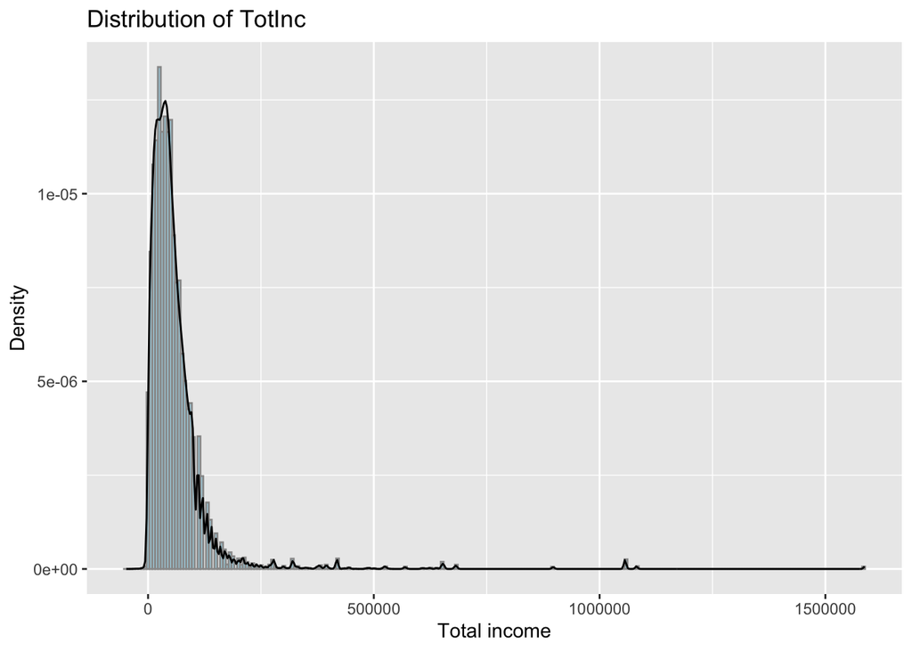

```r
# density curve with the histogram
ggplot(df3, aes(x=TotInc, y=after_stat(density))) +
  geom_histogram(fill="lightblue", color="grey60", bins = 262) +
  geom_density() + ggtitle("Distribution of TotInc") +
  xlab("Total income") + ylab("Density")
```

## Variable Type Conversion

```r
# check class
sapply(df3, class)
```

```
## $WEIGHT
## [1] "numeric"
##
## $AGEGRP
## [1] "haven_labelled" "vctrs_vctr"     "double"
##
## $MarStH
## [1] "haven_labelled" "vctrs_vctr"     "double"
##
## $Sex
## [1] "haven_labelled" "vctrs_vctr"     "double"
##
## $GENSTAT
## [1] "haven_labelled" "vctrs_vctr"     "double"
##
## $IMMCAT5
## [1] "haven_labelled" "vctrs_vctr"     "double"
##
## $CIP2011
## [1] "haven_labelled" "vctrs_vctr"     "double"
##
## $HDGREE
## [1] "haven_labelled" "vctrs_vctr"     "double"
##
## $TotInc
## [1] "numeric"
##
## $MOB1
## [1] "haven_labelled" "vctrs_vctr"     "double"
##
## $KOL
## [1] "haven_labelled" "vctrs_vctr"     "double"
##
## $Citizen
## [1] "haven_labelled" "vctrs_vctr"     "double"
##
## $COW
## [1] "haven_labelled" "vctrs_vctr"     "double"
##
## $FPTWK
```

[output cut: 31 more lines]

```
##
## $NAICS
## [1] "haven_labelled" "vctrs_vctr"     "double"
##
## $NOCS
## [1] "haven_labelled" "vctrs_vctr"     "double"
##
## $CfSize
## [1] "haven_labelled" "vctrs_vctr"     "double"
##
## $HHSIZE
## [1] "haven_labelled" "vctrs_vctr"     "double"
##
## $DETH123
## [1] "haven_labelled" "vctrs_vctr"     "double"
```

```r
# convert to factor
cols <- c("AGEGRP", "MarStH", "Sex", "GENSTAT", "IMMCAT5", "CIP2011", "HDGREE", "MOB1", "KOL", "Citizen", "COW",
          "FPTWK", "LSTWRK", "WKSWRK", "BedRm", "CONDO", "DTYPE", "HCORENEED_IND", "NOS", "REPAIR", "ROOMS",
          "DPGRSUM", "NAICS", "NOCS", "CfSize", "HHSIZE", "DETH123")

df3[cols] <- lapply(df3[cols], as.factor)

# confirm class
sapply(df3, class)
```

```
##        WEIGHT        AGEGRP        MarStH           Sex       GENSTAT
##     "numeric"      "factor"      "factor"      "factor"      "factor"
##       IMMCAT5       CIP2011        HDGREE        TotInc          MOB1
##      "factor"      "factor"      "factor"     "numeric"      "factor"
##           KOL       Citizen           COW         FPTWK        LSTWRK
##      "factor"      "factor"      "factor"      "factor"      "factor"
##        WKSWRK         BedRm         CONDO         DTYPE HCORENEED_IND
##      "factor"      "factor"      "factor"      "factor"      "factor"
##           NOS        REPAIR         ROOMS       DPGRSUM         NAICS
##      "factor"      "factor"      "factor"      "factor"      "factor"
##          NOCS        CfSize        HHSIZE       DETH123
##      "factor"      "factor"      "factor"      "factor"
```

All explanatory variables are categorical ones.

```r
str(df3)
```

```
## tibble [434,778 × 29] (S3: tbl_df/tbl/data.frame)
##  $ WEIGHT       : num [1:434778] 37 37.1 37 37 37 ...
##   ..- attr(*, "label")= chr "Individuals weighting factor"
##   ..- attr(*, "format.spss")= chr "F17.13"
##   ..- attr(*, "display_width")= int 18
##  $ AGEGRP       : Factor w/ 16 levels "6","7","8","9",..: 6 10 9 3 6 6 6 7 3 6 ...
##  $ MarStH       : Factor w/ 6 levels "1","2","3","4",..: 2 3 2 1 3 2 2 2 1 2 ...
##  $ Sex          : Factor w/ 2 levels "1","2": 2 1 2 2 2 1 1 1 2 2 ...
##  $ GENSTAT      : Factor w/ 4 levels "1","2","3","4": 4 4 4 4 3 2 4 4 4 1 ...
##  $ IMMCAT5      : Factor w/ 6 levels "1","2","3","21",..: 1 1 1 1 1 1 1 1 1 4 ...
##  $ CIP2011      : Factor w/ 12 levels "1","2","3","4",..: 8 5 11 12 12 4 12 4 12 7 ...
##  $ HDGREE       : Factor w/ 13 levels "1","2","3","4",..: 4 6 3 2 2 9 2 7 2 9 ...
##  $ TotInc       : num [1:434778] 97000 30000 53000 27000 43000 72000 58000 6000 24000 120000 ...
##   ..- attr(*, "label")= chr "Income: Total income"
##   ..- attr(*, "format.spss")= chr "F8.0"
```

[output cut: 21 more lines]

## Training and Testing indicator

```r
# set seed for reproducibility
set.seed(123)

# leave 20% of dataset for testing
test <- sample(c(FALSE, TRUE), nrow(df3), replace=TRUE, prob=c(0.8,0.2))

# size of test set
sum(test)
```

```
## [1] 87123
```

```r
# size of training set
train <- !test
sum(train)
```

```
## [1] 347655
```

An **80-20 split** was applied to the dataset, resulting in 87,123 records in the test set and 347,655 records in the training set.

# Models

Individual weights associated with each observation are passed into all three kinds of models as the **weight parameter** to ensure that the results are generalisable to the entire Canadian population.

## Regeression Model

### Multiple Regression

```r
# fit the weighted multiple regression model
MF <- lm(TotInc ~ AGEGRP + MarStH + Sex + GENSTAT + IMMCAT5 + CIP2011 + HDGREE + MOB1 + KOL + Citizen + COW
         + FPTWK + LSTWRK + WKSWRK + BedRm + CONDO + DTYPE+ HCORENEED_IND+ NOS+ REPAIR+ ROOMS + DPGRSUM
         + NAICS + NOCS + CfSize + HHSIZE + DETH123, weights = WEIGHT, data = df3, subset = train)

# view the results
summary(MF)
```

```
##
## Call:
## lm(formula = TotInc ~ AGEGRP + MarStH + Sex + GENSTAT + IMMCAT5 +
##     CIP2011 + HDGREE + MOB1 + KOL + Citizen + COW + FPTWK + LSTWRK +
##     WKSWRK + BedRm + CONDO + DTYPE + HCORENEED_IND + NOS + REPAIR +
##     ROOMS + DPGRSUM + NAICS + NOCS + CfSize + HHSIZE + DETH123,
##     data = df3, subset = train, weights = WEIGHT)
##
## Weighted Residuals:
##      Min       1Q   Median       3Q      Max
## -1460532  -149185   -37483    73131  9258342
##
## Coefficients: (2 not defined because of singularities)
##                  Estimate Std. Error t value Pr(>|t|)
## (Intercept)      107329.5     4309.1  24.908  < 2e-16 ***
## AGEGRP7             313.0     1182.9   0.265 0.791335
## AGEGRP8           -2975.9     1067.7  -2.787 0.005316 **
## AGEGRP9           -2677.6     1122.1  -2.386 0.017022 *
## AGEGRP10           4412.5     1144.5   3.855 0.000116 ***
## AGEGRP11          10312.2     1152.6   8.947  < 2e-16 ***
## AGEGRP12          15588.9     1157.1  13.472  < 2e-16 ***
## AGEGRP13          18471.8     1158.9  15.939  < 2e-16 ***
## AGEGRP14          19725.6     1156.4  17.058  < 2e-16 ***
## AGEGRP15          21080.6     1168.8  18.037  < 2e-16 ***
## AGEGRP16          22050.9     1207.1  18.268  < 2e-16 ***
## AGEGRP17          24379.3     1302.4  18.719  < 2e-16 ***
## AGEGRP18          28404.9     1588.2  17.885  < 2e-16 ***
## AGEGRP19          32842.1     2287.5  14.357  < 2e-16 ***
## AGEGRP20          34595.5     3768.7   9.180  < 2e-16 ***
## AGEGRP21          37352.2     7200.6   5.187 2.13e-07 ***
## MarStH2           10569.0      489.9  21.573  < 2e-16 ***
## MarStH3            6719.9      527.3  12.744  < 2e-16 ***
## MarStH4            8818.2      943.7   9.344  < 2e-16 ***
## MarStH5            6039.7      673.1   8.974  < 2e-16 ***
## MarStH6            8394.5     1260.9   6.658 2.79e-11 ***
## Sex2              17614.4      303.2  58.096  < 2e-16 ***
## GENSTAT2           1757.8     2217.5   0.793 0.427958
## GENSTAT3          -1216.4     2219.2  -0.548 0.583616
## GENSTAT4          -2416.3     2178.7  -1.109 0.267408
## IMMCAT52           2012.4     2366.5   0.850 0.395105
```

[output cut: 116 more lines]

```
## CfSize6           13229.1     1495.7   8.845  < 2e-16 ***
## CfSize7           12949.0     2188.4   5.917 3.28e-09 ***
## HHSIZE2           -9232.4      722.2 -12.784  < 2e-16 ***
## HHSIZE3          -14495.4      841.0 -17.236  < 2e-16 ***
## HHSIZE4          -18347.4      943.2 -19.452  < 2e-16 ***
## HHSIZE5          -21066.4     1069.1 -19.705  < 2e-16 ***
## HHSIZE6          -25636.9     1327.8 -19.308  < 2e-16 ***
## HHSIZE7          -29787.5     1500.3 -19.854  < 2e-16 ***
## DETH1232           1252.6      280.5   4.466 7.96e-06 ***
## ---
## Signif. codes:  0 '***' 0.001 '**' 0.01 '*' 0.05 '.' 0.1 ' ' 1
##
## Residual standard error: 442700 on 347506 degrees of freedom
## Multiple R-squared:  0.227,  Adjusted R-squared:  0.2267
## F-statistic: 689.5 on 148 and 347506 DF,  p-value: < 2.2e-16
```

Multiple regression model returned a relatively low **R-squared score of 0.227**, signaling a poor fit that is capable of explaining only 22.7% of the variation in individual income. It thus be concluded that multiple regression is largely ineffective at producing accurate numerical predictions of income here.

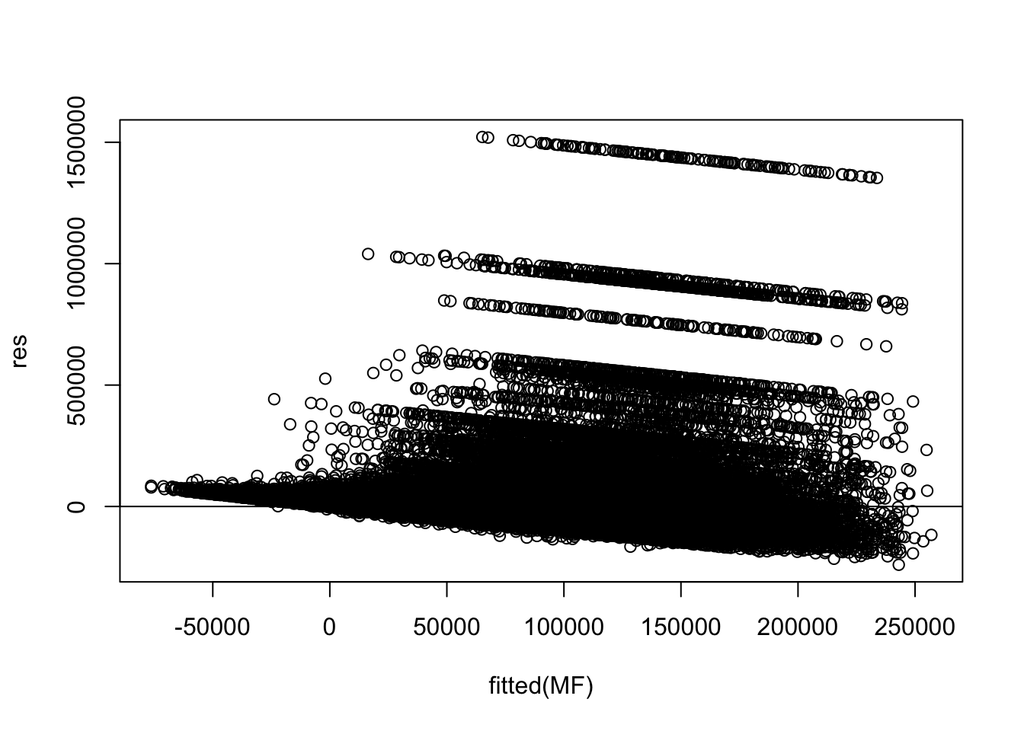

```r
# residual plots
res <- resid(MF)
plot(fitted(MF), res)
abline(0,0)
```

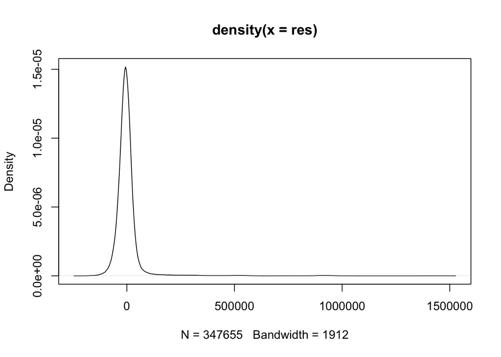

```r
plot(density(res))
```

## Classification Model

Values of the income variable are first divided into **five bins** based on the **2015 federal income tax brackets** to render the dataset suitable for a classification approach. Another binning method that separates income into only **two categories** based on the data’s **median value of 44,000** is also implemented to serve as an additional classification test.

```r
# decide intervals for 5 bins
table(df3$TotInc)
```

```
##
##  -48000  -47000  -44000  -40000  -37000  -35000  -34000  -33000  -30000  -29000
##       1       1       1       1       1       1       1       1       8       2
##  -28000  -27000  -26000  -25000  -24000  -23000  -22000  -21000  -20000  -19000
##       1       3       1       5       4       3       2       3       6       1
##  -18000  -17000  -16000  -15000  -14000  -13000  -12000  -11000  -10000   -9000
##       4       5       4       5      11      11       7      10      22      16
##   -8000   -7000   -6000   -5000   -4000   -3000   -2000   -1000      -1       1
##      20      26      29      36      55      67      91     117      76    2016
##    1000    2000    3000    4000    5000    6000    7000    8000    9000   10000
##    3758    3254    3437    3493    3635    3703    3840    4032    4318    4531
##   11000   12000   13000   14000   15000   16000   17000   18000   19000   20000
##    4699    4852    5022    5101    5143    5141    5149    5224    5116    5317
##   21000   22000   23000   24000   25000   26000   27000   28000   29000   30000
##    5164    5141    5245    5210    5306    5088    5197    5241    5341    5208
```

[output cut: 38 more lines]

The range of TOTINC spans from -$48,000 to $1,586,814, with a median of $44,000.

```r
# calculate the median value of TotInc
median(df3$TotInc)
```

```
## [1] 44000
```

### Random Forest

#### Five Bins

Income levels and ranges for each bin is as follows:

• Low: $0 or less

• Low-Medium: $1 to $44,701

• Medium: $44,702 to $89,401

• Medium-High: $89,402 to $138,586

• High: Over $138,586

```r
# create breaks for the cut function
breaks5 <- c(-60000, 10, 44701, 89401, 138586, 1600000)

# minimum -48000/maximum 1586814 -> set -60000/1600000 as the first/last value in breaks
# based on 2015 Federal Tax Brackets[44,701(included) 89,401(included) 138,586(included) over]

# Values that would have been rounded to zero have been replaced by 1 or -1.
# numbers of records: -1(76) 1(2016)
# next value: 1000 -> set 10 as the second value in breaks -> low: under zero
# values near 44,701: 44,000 and 45,000 -> set 44,701 -> Low-Medium
# values near 89,401: 89,000 and 90,000 -> set 89,401 -> Medium
# values near 138,586: 130,000 and 140,000 -> set 138,586 -> Medium-High
```

```r
# create labels for the new factor variable
labels5 <- c("Low", "Low-Medium", "Medium", "Medium-High", "High")
```

```r
# categorize the values in TotInc and create a new variable
df3$TotInc5 <- cut(df3$TotInc, breaks = breaks5, labels = labels5)

summary(df3$TotInc5)
```

```
##         Low  Low-Medium      Medium Medium-High        High
##        2675      216348      147934       44565       23256
```

It should be noted that the number of observations in each bracket is **not evenly divided**. A total of 216,348 observations fall into the low-medium category and another 147,934 belong to the medium category.

```r
train_weights <- df3$WEIGHT[train]

set.seed(123)

RF5 <- randomForest(TotInc5 ~ AGEGRP + MarStH + Sex + GENSTAT + IMMCAT5 + CIP2011 + HDGREE + MOB1 + KOL + Citizen
                    + COW + FPTWK + LSTWRK + WKSWRK + BedRm + CONDO + DTYPE + HCORENEED_IND + NOS+ REPAIR+ ROOMS
                    + DPGRSUM + NAICS + NOCS + CfSize + HHSIZE + DETH123,
                    data = df3, subset = train, weights = train_weights, ntree=10)

# result
print(RF5)
```

```
##
## Call:
##  randomForest(formula = TotInc5 ~ AGEGRP + MarStH + Sex + GENSTAT +      IMMCAT5 + CIP2011 + HDGREE + MOB1 + KOL + Citizen + COW +      FPTWK + LSTWRK + WKSWRK + BedRm + CONDO + DTYPE + HCORENEED_IND +      NOS + REPAIR + ROOMS + DPGRSUM + NAICS + NOCS + CfSize +      HHSIZE + DETH123, data = df3…
##                Type of random forest: classification
##                      Number of trees: 10
## No. of variables tried at each split: 5
##
##         OOB estimate of  error rate: 39.16%
## Confusion matrix:
##             Low Low-Medium Medium Medium-High High class.error
## Low          69       1752    222          46   32   0.9674682
## Low-Medium  875     133557  32118        3301 1492   0.2205284
## Medium      173      38787  63217       11200 3809   0.4605414
## Medium-High  42       5763  17789        8290 3303   0.7644016
## High         32       2871   6972        4217 4269   0.7674963
```

```r
# predicted class
RF5.pred <- predict(RF5, newdata=subset(df3,test), type="class")

# confusion matrix
test.ct5 <- table(Predicted=RF5.pred, Actual=df3$TotInc5[test]); test.ct5
```

```
##              Actual
## Predicted       Low Low-Medium Medium Medium-High  High
##   Low             3         16      0           1     0
##   Low-Medium    465      35251   9062        1154   606
##   Medium         55       7518  18095        5204  1969
##   Medium-High     5        337   1888        1935   963
##   High            2        138    551         735  1170
```

```r
# Accuracy
sum(diag(test.ct5)) / sum(test.ct5)
```

```
## [1] 0.6479804
```

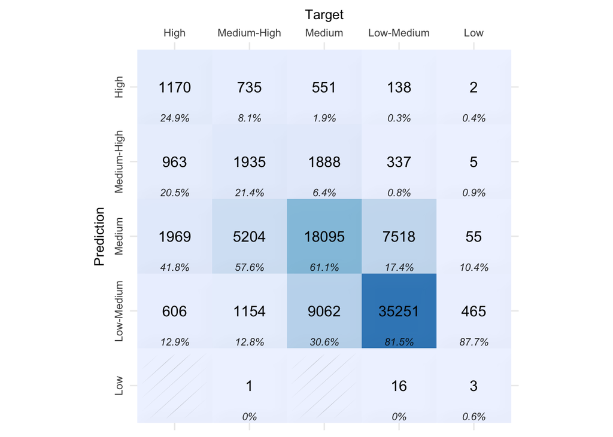

```r
# library(ggimage)
# library(rsvg)
# library(cvms)
cm5_se <- confusion_matrix(targets = df3$TotInc5[test], predictions = RF5.pred)
plot_confusion_matrix(cm5_se$`Confusion Matrix`[[1]],
                      class_order =  c("Low", "Low-Medium", "Medium", "Medium-High", "High"),
                      add_row_percentages = FALSE,
                      add_normalized = FALSE,
                      font_col_percentages = font(size = 3),
                      add_arrows = FALSE)
```

```r
# get the variable importance
var_imp5 <- importance(RF5); print(var_imp5)
```

```
##               MeanDecreaseGini
## AGEGRP              20759.3855
## MarStH               8051.5339
## Sex                  3167.9019
## GENSTAT              4793.9717
## IMMCAT5              3261.9021
## CIP2011             11430.6900
## HDGREE              13843.4258
## MOB1                 3301.7154
## KOL                  4822.7214
## Citizen              1887.4742
## COW                  4224.4965
## FPTWK                9089.0502
## LSTWRK               1388.4461
## WKSWRK              11325.0897
## BedRm                7833.3688
## CONDO                1689.7937
## DTYPE                4438.6529
## HCORENEED_IND        4478.6187
## NOS                   784.1332
## REPAIR               5081.8078
## ROOMS               14505.3539
## DPGRSUM              5699.9736
## NAICS               20853.0293
## NOCS                15250.3355
## CfSize               7420.3939
## HHSIZE               8198.7458
## DETH123              3798.5517
```

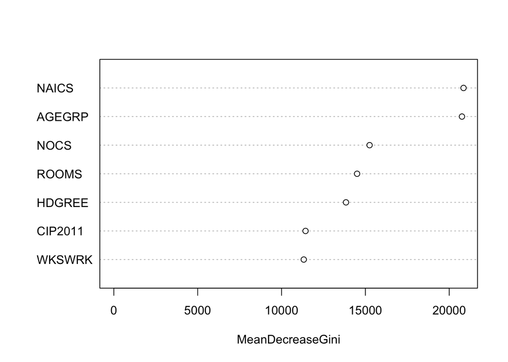

```r
# get variables first
varImpPlot(RF5, sort = TRUE, n.var = 7, main="")
```

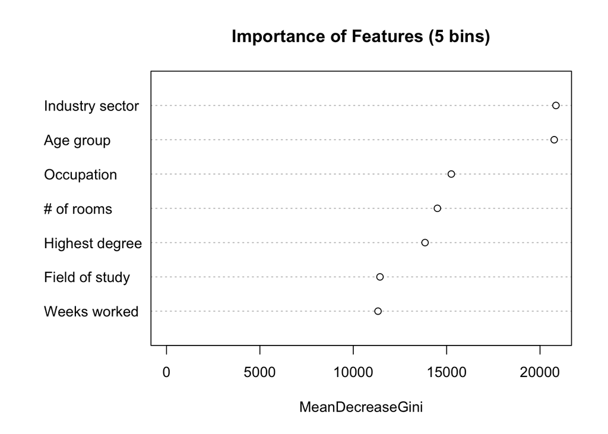

```r
varImpPlot(RF5, sort = T, n.var = 7, main = "Importance of Features (5 bins)",
           labels=c("Weeks worked", "Field of study", "Highest degree", "# of rooms", "Occupation",
                    "Age group","Industry sector"))
```

```r
# calculate precision for each class
precision5 <- diag(test.ct5) / colSums(test.ct5); precision5
```

```
##         Low  Low-Medium      Medium Medium-High        High
## 0.005660377 0.814863615 0.611400189 0.214309447 0.248513169
```

#### Two Bins

```r
# create breaks for the cut function
break2 <- c(-60000, 44701, 1600000)

# create labels for the new factor variable
label2 <- c("<= $44K", "Over $44K")

# categorize the values in TotInc
df3$TotInc2 <- cut(df3$TotInc, breaks = break2, labels = label2)

summary(df3$TotInc2)
```

```
##   <= $44K Over $44K
##    219023    215755
```

Income observations are split into two categories, with 219,023 having a total income lower or equal to the median value of $44,000 and 215,755 having an income above it.

```r
train_weights <- df3$WEIGHT[train]

set.seed(2023)
RF2 <- randomForest(TotInc2 ~ AGEGRP + MarStH + Sex + GENSTAT + IMMCAT5 + CIP2011 + HDGREE + MOB1 + KOL + Citizen
                    + COW + FPTWK + LSTWRK + WKSWRK + BedRm + CONDO + DTYPE + HCORENEED_IND + NOS + REPAIR
                    + ROOMS + DPGRSUM + NAICS + NOCS + CfSize + HHSIZE + DETH123,
                    data = df3, subset = train, weights = train_weights, ntree=10)

print(RF2)
```

```
##
## Call:
##  randomForest(formula = TotInc2 ~ AGEGRP + MarStH + Sex + GENSTAT +      IMMCAT5 + CIP2011 + HDGREE + MOB1 + KOL + Citizen + COW +      FPTWK + LSTWRK + WKSWRK + BedRm + CONDO + DTYPE + HCORENEED_IND +      NOS + REPAIR + ROOMS + DPGRSUM + NAICS + NOCS + CfSize +      HHSIZE + DETH123, data = df3…
##                Type of random forest: classification
##                      Number of trees: 10
## No. of variables tried at each split: 5
##
##         OOB estimate of  error rate: 23.34%
## Confusion matrix:
##           <= $44K Over $44K class.error
## <= $44K    127844     45528   0.2626030
## Over $44K   34757    135855   0.2037196
```

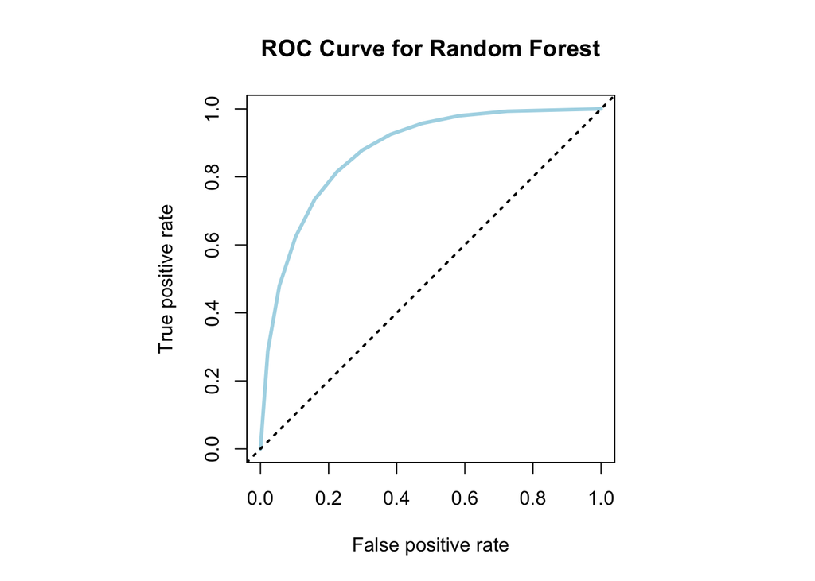

```r
RF2.pred <- predict(RF2, newdata=subset(df3,test), type="class")
RF2.prob <- predict(RF2, newdata=subset(df3,test), type="prob")

# library(ROCR)
par(pty = "s")
plot(performance(prediction(RF2.prob[,2], df3$TotInc2[test]), "tpr", "fpr"),
     main = "ROC Curve for Random Forest", lwd= 3, col="lightblue")
abline(a=0, b= 1, lty=3, lwd = 2)
```

```r
test.ct2 <- table(Predicted=RF2.pred, Actual=df3$TotInc2[test]); test.ct2
```

```
##            Actual
## Predicted   <= $44K Over $44K
##   <= $44K     32850      7155
##   Over $44K   10940     36178
```

```r
# accuracy
sum(diag(test.ct2)) / sum(test.ct2)
```

```
## [1] 0.7923051
```

```r
# calculate precision for each class
precision <- diag(test.ct2) / rowSums(test.ct2); precision
```

```
##   <= $44K Over $44K
## 0.8211474 0.7678170
```

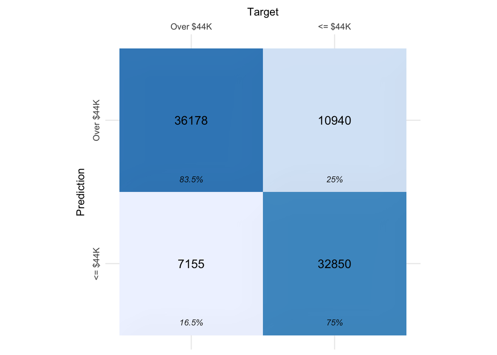

```r
# library(ggimage)
# library(rsvg)
# library(cvms)
cm2_se <- confusion_matrix(targets = df3$TotInc2[test], predictions = RF2.pred)

plot_confusion_matrix(cm2_se$`Confusion Matrix`[[1]],  class_order = c("<= $44K", "Over $44K"),
                      add_row_percentages = FALSE, add_normalized = FALSE,
                      font_col_percentages = font(size = 3), add_arrows = FALSE)
```

```r
# get the variable importance
var_imp2 <- importance(RF2); print(var_imp2)
```

```
##               MeanDecreaseGini
## AGEGRP              22789.7004
## MarStH               6478.3637
## Sex                  3062.2666
## GENSTAT              2747.9364
## IMMCAT5              2452.9595
## CIP2011              9025.1992
## HDGREE               9874.0049
## MOB1                 2248.7743
## KOL                  3344.6886
## Citizen              1237.5312
## COW                  3976.7982
## FPTWK               10502.8517
## LSTWRK               1246.7044
## WKSWRK               9306.1886
## BedRm                4855.7923
## CONDO                1143.5400
## DTYPE                2857.0682
## HCORENEED_IND        6468.2581
## NOS                   789.9489
## REPAIR               3058.9090
## ROOMS                9548.0913
## DPGRSUM              4014.5124
## NAICS               20881.1111
## NOCS                12559.3181
## CfSize               4483.3740
## HHSIZE               5319.9055
## DETH123              2109.0505
```

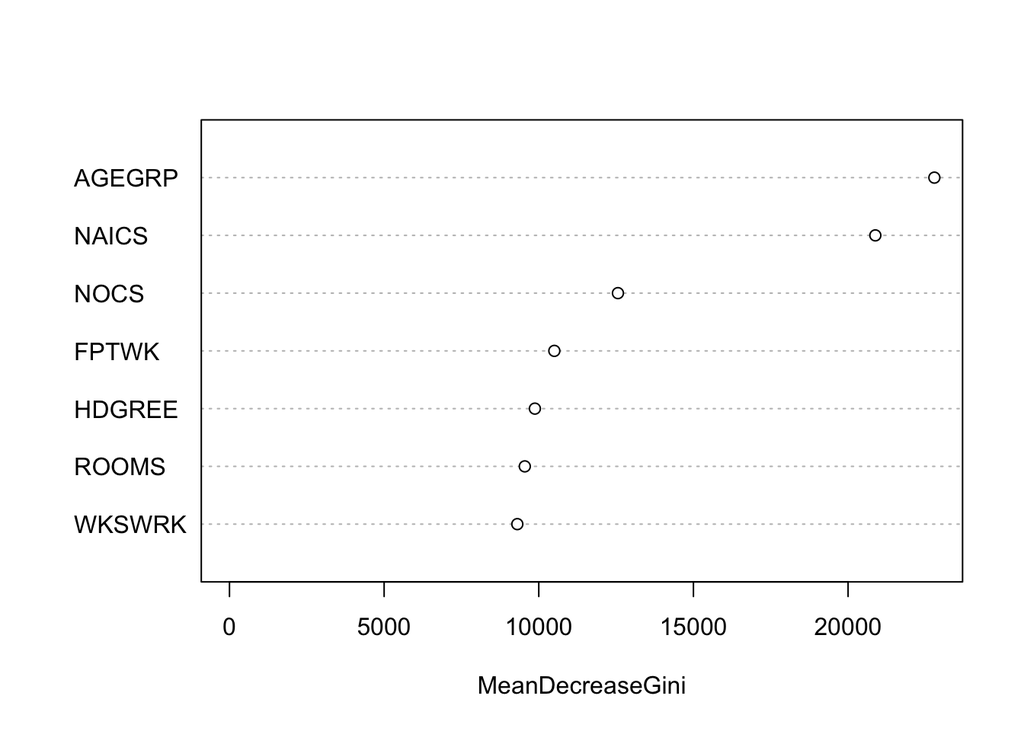

```r
varImpPlot(RF2, sort = TRUE, n.var = 7, main="")
```

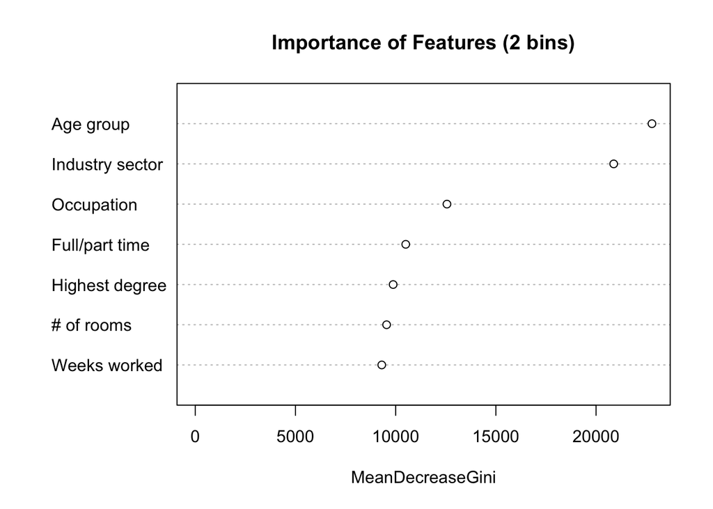

```r
varImpPlot(RF2, sort = T, n.var = 7, main = "Importance of Features (2 bins)",
           labels=c("Weeks worked","# of rooms", "Highest degree", "Full/part time",
                    "Occupation", "Industry sector", "Age group"))
```

```r
# precision of 0
p2_0 = test.ct2[1, 1] / sum(test.ct2[1, ]); p2_0
```

```
## [1] 0.8211474
```

```r
# recall of 0
r2_0 = test.ct2[1, 1] / sum(test.ct2[,1]); r2_0
```

```
## [1] 0.7501713
```

```r
# F-1 score of 0
f2_0 = 2 * p2_0  * r2_0 / (p2_0 + r2_0); f2_0
```

```
## [1] 0.7840563
```

```r
# precision of 1
p2_1 = test.ct2[2, 2] / sum(test.ct2[2, ]); p2_1
```

```
## [1] 0.767817
```

```r
# recall of 1
r2_1 = test.ct2[2, 2] / sum(test.ct2[, 2]); r2_1
```

```
## [1] 0.8348833
```

```r
# F-1 score of 1
f2_1 = 2 * p2_1 * r2_1 / (p2_1 + r2_1); f2_1
```

```
## [1] 0.7999469
```

### Naive Bayes

Since R does not have a suitable package for handling weights in Naive Bayes modeling, Python was used instead, utilizing the Scikit-learn library. The objective here is to create an appropriate dataset while **ensuring that the training and test sets remain consistent** for the modeling process in Python.

#### Create Suitable Variables

```r
sapply(df4, class)
```

```
## $WEIGHT
## [1] "numeric"
##
## $AGEGRP
## [1] "haven_labelled" "vctrs_vctr"     "double"
##
## $MarStH
## [1] "haven_labelled" "vctrs_vctr"     "double"
##
## $Sex
## [1] "haven_labelled" "vctrs_vctr"     "double"
##
## $GENSTAT
## [1] "haven_labelled" "vctrs_vctr"     "double"
##
## $IMMCAT5
## [1] "haven_labelled" "vctrs_vctr"     "double"
##
## $CIP2011
## [1] "haven_labelled" "vctrs_vctr"     "double"
##
## $HDGREE
## [1] "haven_labelled" "vctrs_vctr"     "double"
##
## $TotInc
## [1] "numeric"
##
## $MOB1
## [1] "haven_labelled" "vctrs_vctr"     "double"
##
## $KOL
## [1] "haven_labelled" "vctrs_vctr"     "double"
##
## $Citizen
## [1] "haven_labelled" "vctrs_vctr"     "double"
##
## $COW
## [1] "haven_labelled" "vctrs_vctr"     "double"
##
## $FPTWK
```

[output cut: 31 more lines]

```
##
## $NAICS
## [1] "haven_labelled" "vctrs_vctr"     "double"
##
## $NOCS
## [1] "haven_labelled" "vctrs_vctr"     "double"
##
## $CfSize
## [1] "haven_labelled" "vctrs_vctr"     "double"
##
## $HHSIZE
## [1] "haven_labelled" "vctrs_vctr"     "double"
##
## $DETH123
## [1] "haven_labelled" "vctrs_vctr"     "double"
```

```r
#change labels
levels(df3$AGEGRP)
```

```
##  [1] "6"  "7"  "8"  "9"  "10" "11" "12" "13" "14" "15" "16" "17" "18" "19" "20"
## [16] "21"
```

```r
df4$AGEGRP <- factor(df4$AGEGRP,
                     levels=c("6" , "7" , "8" , "9" , "10", "11", "12", "13" ,"14", "15" ,"16" ,"17" ,"18",
                              "19", "20" ,"21"),
                     labels=c("0","1","2","3","4","5","6" , "7" , "8" , "9" , "10", "11", "12", "13" ,"14",
                              "15"))

table(df4$AGEGRP)
```

```
##
##     0     1     2     3     4     5     6     7     8     9    10    11    12
##  8437 13113 40495 43313 45120 44095 43558 45345 51413 46657 30677 14979  5249
##    13    14    15
##  1686   508   133
```

```r
levels(df3$MarStH)
```

```
## [1] "1" "2" "3" "4" "5" "6"
```

```r
df4$MarStH <- factor(df4$MarStH,
                     levels = c("1", "2", "3", "4", "5", "6"),
                     labels = c("0", "1", "2", "3", "4", "5"))
```

```r
levels(df3$Sex)
```

```
## [1] "1" "2"
```

```r
df4$Sex <- factor(df4$Sex,
                  levels = c("1", "2"),
                  labels = c("0", "1"))
```

```r
levels(df3$GENSTAT)
```

```
## [1] "1" "2" "3" "4"
```

```r
df4$GENSTAT <- factor(df4$GENSTAT,
                      levels = c("1", "2", "3", "4"),
                      labels = c("0", "1", "2", "3"))
```

```r
levels(df3$IMMCAT5)
```

```
## [1] "1"  "2"  "3"  "21" "22" "23"
```

```r
df4$IMMCAT5 <- factor(df4$IMMCAT5,
                      levels = c("1",  "2",  "3",  "21", "22", "23"),
                      labels = c("0", "1",  "2",  "3", "4", "5"))
```

```r
levels(df3$CIP2011)
```

```
##  [1] "1"  "2"  "3"  "4"  "5"  "6"  "7"  "8"  "9"  "10" "11" "13"
```

```r
df4$CIP2011 <- factor(df4$CIP2011,
                      levels = c("1", "2",  "3",  "4",  "5",  "6",  "7",  "8",  "9",  "10", "11", "13"),
                      labels = c("0", "1",  "2",  "3",  "4",  "5",  "6",  "7",  "8",  "9",  "10", "11"))
```

```r
levels(df3$HDGREE)
```

```
##  [1] "1"  "2"  "3"  "4"  "5"  "6"  "7"  "8"  "9"  "10" "11" "12" "13"
```

```r
df4$HDGREE <- factor(df4$HDGREE,
                     levels = c("1", "2",  "3",  "4",  "5",  "6",  "7",  "8",  "9",  "10", "11", "12", "13"),
                     labels = c("0", "1",  "2",  "3",  "4",  "5",  "6",  "7",  "8",  "9",  "10", "11", "12"))
```

```r
levels(df3$MOB1)
```

```
## [1] "1" "2" "3" "4" "5" "6"
```

```r
df4$MOB1 <- factor(df4$MOB1,
                   levels = c("1", "2",  "3",  "4",  "5",  "6"),
                   labels = c("0", "1",  "2",  "3",  "4",  "5"))
```

```r
levels(df3$KOL)
```

```
## [1] "1" "2" "3" "4"
```

```r
df4$KOL <- factor(df4$KOL,
                  levels = c("1", "2",  "3",  "4"),
                  labels = c("0", "1",  "2",  "3"))
```

```r
levels(df3$Citizen)
```

```
## [1] "1" "2" "3"
```

```r
df4$Citizen <- factor(df4$Citizen,
                      levels = c("1", "2",  "3"),
                      labels = c("0", "1",  "2"))
```

```r
levels(df3$COW)
```

```
## [1] "1" "2" "3" "4" "5" "6"
```

```r
df4$COW <- factor(df4$COW,
                  levels = c("1", "2",  "3",  "4",  "5",  "6"),
                  labels = c("0", "1",  "2",  "3",  "4",  "5"))
```

```r
levels(df3$FPTWK)
```

```
## [1] "1" "2"
```

```r
df4$FPTWK <- factor(df4$FPTWK,
                    levels = c("1", "2"),
                    labels = c("0", "1"))
```

```r
levels(df3$LSTWRK)
```

```
## [1] "2" "3"
```

```r
df4$LSTWRK <- factor(df4$LSTWRK,
                     levels = c("2", "3"),
                     labels = c("0", "1"))
```

```r
levels(df3$WKSWRK)
```

```
## [1] "1" "2" "3" "4" "5" "6"
```

```r
df4$WKSWRK <- factor(df4$WKSWRK,
                     levels = c("1", "2",  "3",  "4",  "5",  "6"),
                     labels = c("0", "1",  "2",  "3",  "4",  "5"))
```

```r
levels(df3$BedRm)
```

```
## [1] "0" "1" "2" "3" "4" "5"
```

```r
df4$BedRm <- factor(df4$BedRm)
```

```r
levels(df3$CONDO)
```

```
## [1] "0" "1"
```

```r
df4$CONDO <- factor(df4$CONDO)
```

```r
levels(df3$DTYPE)
```

```
## [1] "1" "2" "3"
```

```r
df4$DTYPE <- factor(df4$DTYPE,
                    levels = c("1", "2",  "3"),
                    labels = c("0", "1",  "2"))
```

```r
levels(df3$HCORENEED_IND)
```

```
## [1] "0"   "100"
```

```r
df4$HCORENEED_IND <- factor(df4$HCORENEED_IND,
                            levels = c("0", "100"),
                            labels = c("0", "1"))
```

```r
levels(df3$NOS)
```

```
## [1] "0" "1"
```

```r
df4$NOS <- factor(df4$NOS)
```

```r
levels(df3$REPAIR)
```

```
## [1] "1" "2" "3"
```

```r
df4$REPAIR <- factor(df4$REPAIR,
                     levels = c("1", "2",  "3"),
                     labels = c("0", "1",  "2"))
```

```r
levels(df3$ROOMS)
```

```
##  [1] "1"  "2"  "3"  "4"  "5"  "6"  "7"  "8"  "9"  "10" "11"
```

```r
df4$ROOMS <- factor(df4$ROOMS,
                    levels = c("1", "2",  "3",  "4",  "5",  "6",  "7",  "8",  "9",  "10", "11"),
                    labels = c("0", "1",  "2",  "3",  "4",  "5",  "6",  "7",  "8",  "9",  "10"))
```

```r
levels(df3$DPGRSUM)
```

```
##  [1] "1"  "2"  "3"  "4"  "5"  "6"  "7"  "8"  "9"  "10" "11" "12" "13" "14" "15"
```

```r
df4$DPGRSUM <- factor(df4$DPGRSUM,
                      levels = c("1", "2",  "3",  "4",  "5",  "6",  "7",  "8",  "9",  "10", "11", "12", "13",
                                 "14", "15"),
                      labels = c("0", "1",  "2",  "3",  "4",  "5",  "6",  "7",  "8",  "9",  "10", "11", "12",
                                 "13", "14"))
```

```r
levels(df3$NAICS)
```

```
##  [1] "1"  "2"  "3"  "4"  "5"  "6"  "7"  "8"  "9"  "10" "11" "12" "13" "14" "15"
## [16] "16" "17" "18" "19"
```

```r
df4$NAICS <- factor(df4$NAICS,
                    levels = c("1", "2",  "3",  "4",  "5",  "6",  "7",  "8",  "9",  "10", "11", "12", "13", "14",
                               "15", "16", "17","18","19"),
                    labels = c("0", "1",  "2",  "3",  "4",  "5",  "6",  "7",  "8",  "9",  "10", "11", "12", "13",
                               "14", "15", "16", "17","18"))
```

```r
levels(df3$NOCS)
```

```
##  [1] "1"  "2"  "3"  "4"  "5"  "6"  "7"  "8"  "9"  "10"
```

```r
df4$NOCS <- factor(df4$NOCS,
                   levels = c("1", "2",  "3",  "4",  "5",  "6",  "7",  "8",  "9",  "10"),
                   labels = c("0", "1",  "2",  "3",  "4",  "5",  "6",  "7",  "8",  "9"))
```

```r
levels(df3$CfSize)
```

```
## [1] "1" "2" "3" "4" "5" "6" "7"
```

```r
df4$CfSize <- factor(df4$CfSize,
                     levels = c("1", "2",  "3",  "4",  "5",  "6",  "7"),
                     labels = c("0", "1",  "2",  "3",  "4",  "5",  "6"))
```

```r
levels(df3$HHSIZE)
```

```
## [1] "1" "2" "3" "4" "5" "6" "7"
```

```r
df4$HHSIZE <- factor(df4$HHSIZE,
                     levels = c("1", "2",  "3",  "4",  "5",  "6",  "7"),
                     labels = c("0", "1",  "2",  "3",  "4",  "5",  "6"))
```

```r
levels(df3$DETH123)
```

```
## [1] "1" "2"
```

```r
df4$DETH123 <- factor(df4$DETH123,
                      levels = c("1", "2"),
                      labels = c("0", "1"))
```

```r
str(df4)
```

```
## tibble [434,778 × 29] (S3: tbl_df/tbl/data.frame)
##  $ WEIGHT       : num [1:434778] 37 37.1 37 37 37 ...
##   ..- attr(*, "label")= chr "Individuals weighting factor"
##   ..- attr(*, "format.spss")= chr "F17.13"
##   ..- attr(*, "display_width")= int 18
##  $ AGEGRP       : Factor w/ 16 levels "0","1","2","3",..: 6 10 9 3 6 6 6 7 3 6 ...
##  $ MarStH       : Factor w/ 6 levels "0","1","2","3",..: 2 3 2 1 3 2 2 2 1 2 ...
##  $ Sex          : Factor w/ 2 levels "0","1": 2 1 2 2 2 1 1 1 2 2 ...
##  $ GENSTAT      : Factor w/ 4 levels "0","1","2","3": 4 4 4 4 3 2 4 4 4 1 ...
##  $ IMMCAT5      : Factor w/ 6 levels "0","1","2","3",..: 1 1 1 1 1 1 1 1 1 4 ...
##  $ CIP2011      : Factor w/ 12 levels "0","1","2","3",..: 8 5 11 12 12 4 12 4 12 7 ...
##  $ HDGREE       : Factor w/ 13 levels "0","1","2","3",..: 4 6 3 2 2 9 2 7 2 9 ...
##  $ TotInc       : num [1:434778] 97000 30000 53000 27000 43000 72000 58000 6000 24000 120000 ...
##   ..- attr(*, "label")= chr "Income: Total income"
##   ..- attr(*, "format.spss")= chr "F8.0"
```

[output cut: 21 more lines]

#### Create and save training and test sets

```r
# categorize the values in TotInc and create a new variable (5 bins)
df4$TotInc5 <- cut(df4$TotInc, breaks = breaks5, labels = labels5)

# categorize the values in TotInc and create a new variable (2 bins)
df4$TotInc2 <- cut(df4$TotInc, breaks = break2, labels = label2)
```

```r
# obtain and save training data
table(train)
```

```
## train
##  FALSE   TRUE
##  87123 347655
```

```r
df4.train <- subset(df4, train)
write.csv(df4.train, "df4-train.csv", row.names = FALSE)

# obtain and save testing data
df4.test <- subset(df4, test)
write.csv(df4.test, "df4-test.csv", row.names = FALSE)
```

#### Modelling Process

Check **NaiveBayes.ipynb** for details.

# Income Distribution Across Important Features (5 bins)

As an extension of findings on variable importance, the analysis here examines income distribution by features that possessed the greatest mean decrease in Gini. The following bar plots thus represent how income is distributed across the categories of each feature for the Canadian population as a whole based on the distribution of available observations in our target data set.

## Industry Sector and Income Distribution

```r
# number of sample
table(df3$NAICS,df3$TotInc5)
```

```
##
##        Low Low-Medium Medium Medium-High  High
##   1     80       4096   2027         391   211
##   2     10        709   1682        1815  1960
##   3      2        237   1018        1043   598
##   4    247      14462  13291        3738  1612
##   5    125      15947  16359        4586  2075
##   6     44       6092   6326        1967  1484
##   7    430      38168  10460        2014  1232
##   8     84       9426   8817        1820   808
##   9     65       3524   3949        1469   682
##   10    50       5877   8378        2916  2475
##   11    90       3521   2443         654   599
##   12   210      11828  11836        4567  3638
##   13   175      13437   4134         676   352
##   14   146      12841  13610        5092  1071
##   15   126      24458  19949        4453  2230
##   16   202       6534   1852         297   165
##   17   369      26903   2736         314   219
##   18   165      12392   4886         931   407
##   19    55       5896  14181        5822  1438
```

```r
sum(table(df3$NAICS,df3$TotInc5))
```

```
## [1] 434778
```

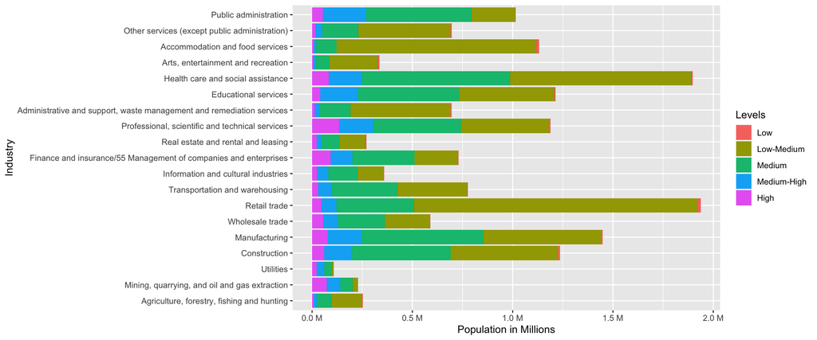

```r
indu<-df3[,c("WEIGHT","TotInc5","NAICS")]

dfff <- indu %>%
  mutate(Industry = recode(NAICS, "1" = "Agriculture, forestry, fishing and hunting",
                           "2" = "Mining, quarrying, and oil and gas extraction",
                           "3" = "Utilities",
                           "4" = "Construction",
                           "5" = "Manufacturing",
                           "6" = "Wholesale trade",
                           "7" = "Retail trade",
                           "8" = "Transportation and warehousing",
                           "9" = "Information and cultural industries",
                           "10" = "Finance and insurance/55 Management of companies and enterprises",
                           "11" = "Real estate and rental and leasing",
                           "12" = "Professional, scientific and technical services",
                           "13" = "Administrative and support, waste management and remediation services",
                           "14" = "Educational services",
                           "15" = "Health care and social assistance",
                           "16" = "Arts, entertainment and recreation",
                           "17" = "Accommodation and food services",
                           "18" = "Other services (except public administration)",
                           "19"= "Public administration"))
colnames(dfff)[2]<-"Levels"

ggplot(data=dfff, aes(x=Industry, y=WEIGHT, fill=Levels)) +
  geom_bar(stat="identity")  +
  ylab("Population in Millions") +
  scale_y_continuous(labels = unit_format(unit = "M", scale = 1e-6))+
  coord_flip()
```

## Occupation and Income Distribution

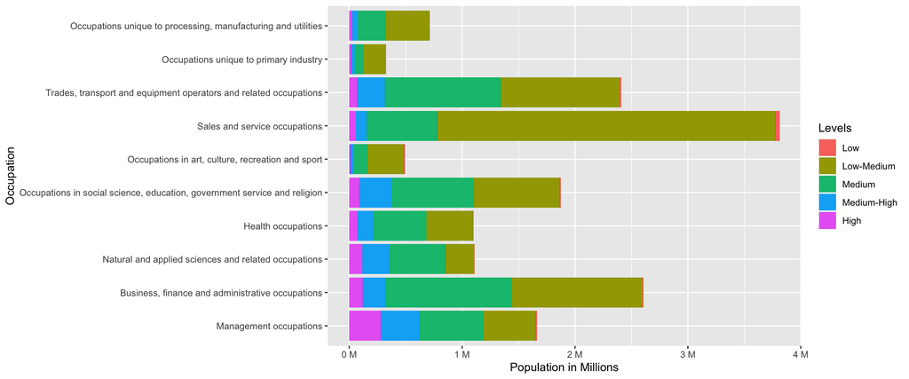

```r
ococ<-df3[,c("WEIGHT","TotInc5","NOCS")]

occupation <- ococ %>%
  mutate(Occupation = recode(NOCS, "1" = "Management occupations",
                             "2" = "Business, finance and administrative occupations",
                             "3" = "Natural and applied sciences and related occupations",
                             "4" = "Health occupations",
                             "5" = "Occupations in social science, education, government service and religion",
                             "6" = "Occupations in art, culture, recreation and sport",
                             "7" = "Sales and service occupations",
                             "8" = "Trades, transport and equipment operators and related occupations",
                             "9" = "Occupations unique to primary industry",
                             "10" = "Occupations unique to processing, manufacturing and utilities"))

colnames(occupation)[2]<-"Levels"

ggplot(data=occupation, aes(x=Occupation, y=WEIGHT, fill=Levels)) +
  geom_bar(stat="identity")  +
  ylab("Population in Millions") +
  scale_y_continuous(labels = unit_format(unit = "M", scale = 1e-6))+
  coord_flip()
```

## Highest Degree Obtained and Income Distribution

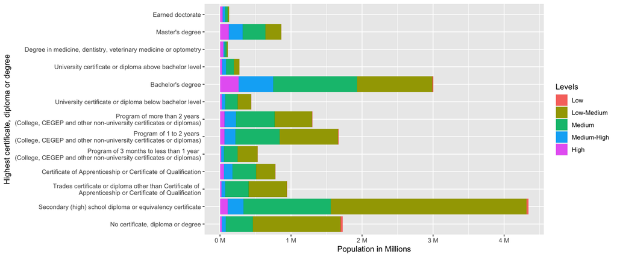

```r
deg<-df3[,c("WEIGHT","TotInc5","HDGREE")]

degree <- deg %>%
  mutate(Degree = recode(HDGREE, "1" = "No certificate, diploma or degree",
                      "2" = "Secondary (high) school diploma or equivalency certificate",
                      "3" = "Trades certificate or diploma other than Certificate of \n Apprenticeship or Certificate of Qualification",
                      "4" = "Certificate of Apprenticeship or Certificate of Qualification",
                      "5" = "Program of 3 months to less than 1 year \n (College, CEGEP and other non-university certificates or diplomas)",
                      "6" = "Program of 1 to 2 years \n (College, CEGEP and other non-university certificates or diplomas)",
                      "7" = "Program of more than 2 years \n (College, CEGEP and other non-university certificates or diplomas)",
                      "8" = "University certificate or diploma below bachelor level",
                      "9" = "Bachelor's degree",
                      "10" = "University certificate or diploma above bachelor level",
                      "11" = "Degree in medicine, dentistry, veterinary medicine or optometry",
                      "12" = "Master's degree",
                      "13"="Earned doctorate"))

colnames(degree)[2]<-"Levels"

ggplot(data=degree, aes(x=Degree, y=WEIGHT, fill=Levels)) +
  geom_bar(stat="identity")  + xlab("Highest certificate, diploma or degree")+
  ylab("Population in Millions") +
  scale_y_continuous(labels = unit_format(unit = "M", scale = 1e-6))+
  coord_flip()
```

Those with **secondary education or below** are most likely to fall into low-medium and low income brackets, while **masters, doctorates, and degrees in the medical industry** have proportionately higher income. It is also worth noting that **earning a Bachelor’s degree** marks a somewhat significant increase in one’s probability of being in the medium-high bracket or above compared to holding a lower degree.

## Age and Income Distribution

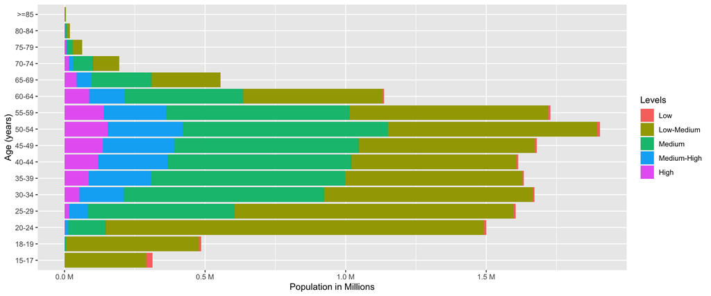

```r
ageage<-df3[,c("WEIGHT","TotInc5","AGEGRP")]

age <- ageage %>%
  mutate(Age = recode(AGEGRP,
                      "1" = "0-4",
                      "2" = "5-6",
                      "3" = "7-9",
                      "4" = "10-11",
                      "5" = "12-14",
                      "6" = "15-17",
                      "7" = "18-19",
                      "8" = "20-24",
                      "9" = "25-29",
                      "10" = "30-34",
                      "11" = "35-39",
                      "12" = "40-44",
                      "13" = "45-49",
                      "14" = "50-54",
                      "15" = "55-59",
                      "16" = "60-64",
                      "17" = "65-69",
                      "18" = "70-74",
                      "19" = "75-79",
                      "20" = "80-84",
                      "21" = ">=85"))

colnames(age)[2]<-"Levels"

ggplot(data=age, aes(x=Age, y=WEIGHT, fill=Levels)) +
  geom_bar(stat="identity")  + xlab("Age (years)")+
  ylab("Population in Millions") +
  scale_y_continuous(labels = unit_format(unit = "M", scale = 1e-6))+
  coord_flip()
```

Income tends to rise the fastest when one enters their **mid-twenties** and begins to drop after **55 years of age**.